# Model reproduction checklist

Breck Baldwin

March 21, 2021

```r
knitr::opts_chunk$set(
    echo = TRUE,
    message = FALSE,
    warning = FALSE,
    results = "hide",
    error = FALSE,
    comment = ''
)
```

# Model overview

This document exists in the repository at https://github.com/codatmo/Liverpool as `model_reproduction_checklist.Rmd` and rendered in html as https://github.com/codatmo/Liverpool/model_reproduction_checklist.html.

The sister page https://codatmo.github.io/Liverpool/index.html describes the model more fully.

This model is part of the CoDatMo (Co)vid (Dat)a (Mo)deling site (https://codatmo.github.io/) which is intended to replicate and make available important COVID models written in Bayesian modeling languages like Stan or PyMC3.

### Validation checklist items

- Model released on github: https://github.com/codatmo/Liverpool
- Problem description
- Model description: Research goals, references, supplementary description as necessary.
- Data
  - Data generating process
  - Data munging and examination
- Stan program
- Running model
  - Small data set to validate model execution (not done)
  - Run on availble data
  - Examine model output
- Model
- Model validation
  - Report posterior diagnostics
  - Prior predictive check parameters/predictions
  - Parameter recovery with simulated data
  - Posterior predictive check
  - Parameter interpretation (not done)
  - Cross validation (not done)
  - Simulation based calibration (SBC) (not done)
- Compute environment

## Problem description

Model goal is to estimate COVID hospitalizations based on reports from 111 calls to government services and/or website reports.

## Model description

See https://codatmo.github.io/Liverpool/index.html for detailed description.

## Data

Actual data is available as described at https://codatmo.github.io/Data/index.html. An .RDS file exists locally at `nhs_regions_111_calls.RDS`.

```r
calls_111.df <- readRDS("data/nhs_regions_111_calls.Rds")
deaths.df <- readRDS("data/nhs_regions_deaths.Rds")

calls_111 <- as.numeric(calls_111.df$London[1:71])
deaths <- as.numeric(deaths.df$London[1:14])
```

There is a script to generate simulated data.

```r
source("src/scripts/generateSimulatedData.R")
generatedData <- generateSimulatedData(
  seed = 0,
  maxTime = 100,
  population = 1000000,
  n_beta_pieces = 20,
  n_rho_calls_111_pieces = 10,
  calls_111_start = 30
)
stan_data_sim <- generatedData$stan_data
stan_data_sim$compute_likelihood <- 1 # controls whether likelihood is computed
ground_truth_sim <- generatedData$ground_truth
```

The script does a fair amount of data munging, see below, but the data analogous to production data are two data sources:

```r
#deaths <- stan_data$deaths
#calls_111 <- stan_data$calls_111
cat(paste(sprintf("Weekly COVID death count=%d, Days of 111_calls (7 days per weekly count)=%d",
                  length(deaths),
                  length(calls_111))))
```

```
Weekly COVID death count=14, Days of 111_calls (7 days per weekly count)=71
```

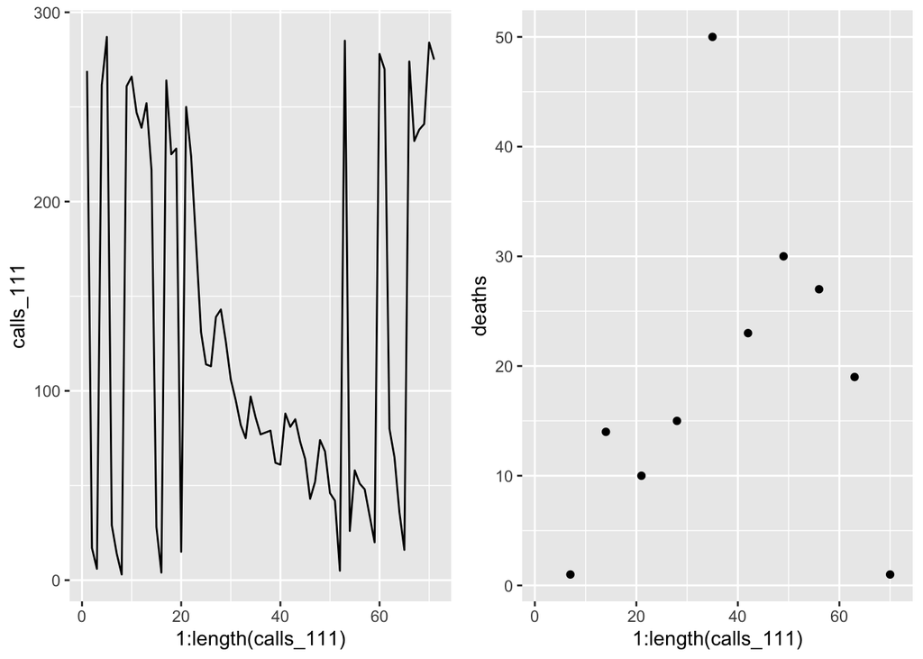

```r
library(ggplot2)
library(tidyr)
library(gridExtra)

day <- 1:length(calls_111)
data.df <- data.frame(calls_111,day)
data.df$deaths <- ifelse(data.df$day %% 7 == 0, deaths[data.df$day %/% 7], NA)

ggplot(data.df) +
  aes(x=1:length(calls_111), y=calls_111) +
  geom_line() -> p1

ggplot(data.df) +
  aes(x=1:length(calls_111), y=deaths) +
  geom_point() -> p2

grid.arrange(p1, p2, ncol=2)
```

### Data munging

```r
# deaths <- stan_data$deaths
# calls_111 <- stan_data$calls_111

# below are constants
T <- 100
maxTime <- T
initial_time <- 0
n_disease_states <- 8
n_beta_pieces <- 20
calls_111_start <- 30
n_rho_calls_111_pieces <- 10
population <- 1e+06

beta_pieceLength <- ceiling(maxTime / n_beta_pieces)
beta_left_t <- seq(0, maxTime - 1, by = beta_pieceLength)
beta_right_t <- c(beta_left_t[2:n_beta_pieces], maxTime + 1)

real_data_length = length(beta_left_t) + length(beta_right_t) + 1
real_data = c(beta_left_t, beta_right_t, population)
integer_data = c(
  maxTime,
  length(beta_left_t),
  length(beta_right_t),
  length(beta_left_t),
  n_disease_states
)
integer_data_length <- length(integer_data)

rho_calls_pieceLength <-
  ceiling((maxTime - calls_111_start) / n_rho_calls_111_pieces)
rho_calls_111_left_t <-
  seq(calls_111_start, maxTime - 1, by = rho_calls_pieceLength)
rho_calls_111_right_t <-
  c(rho_calls_111_left_t[2:n_rho_calls_111_pieces], maxTime + 1)

times <- 1:T
deaths_length <- length(deaths)
deaths_starts <- seq(from = 1, to = deaths_length * 7, by = 7)
deaths_stops <- seq(from = 7, to = deaths_length * 7, by = 7)
calls_111_length <- length(calls_111)

stan_data <- list(
  initial_time = initial_time,
  n_beta_pieces = n_beta_pieces,
  beta_left_t = beta_left_t,
  beta_right_t = beta_right_t,
  T = maxTime,
  times = times,
  n_disease_states = n_disease_states,
  population = population,
  deaths_length = length(deaths),
  deaths_starts = deaths_starts,
  deaths_stops = deaths_stops,
  deaths = deaths,
  real_data_length = length(beta_left_t) + length(beta_right_t) + 1,
  real_data = c(beta_left_t, beta_right_t, population),
  integer_data_length = 5,
  integer_data = c(
    maxTime,
    length(beta_left_t),
    length(beta_right_t),
    length(beta_left_t),
    n_disease_states
  ),
  n_rho_calls_111_pieces = n_rho_calls_111_pieces,
  rho_calls_111_left_t = rho_calls_111_left_t,
  rho_calls_111_right_t = rho_calls_111_right_t,
  calls_111_start = calls_111_start,
  calls_111 = calls_111,
  calls_111_length = calls_111_length,
  compute_likelihood = 1
)

# test that data has been properly munged.
# for (varname in names(stan_data)) {
#   # print(paste("trying:",varname))
#   if (!varname %in% names(stan_data2)) {
#     print(paste("NULL for ", varname))
#   }
#   if (!all(stan_data[[varname]] == stan_data2[[varname]])) {
#     print(paste("mismatch ", varname))
#   }
# }
```

## Stan program

The Stan model is located at `src/models/deaths_and_111_calls.stan`:

```r
stan_file <- "src/models/deaths_and_111_calls.stan"
lines <- readLines(stan_file)
cat(paste(lines, "\n", sep=""), sep="")
```

```
functions {
  real[] seeiittd(real time,
                  real[] state,
                  real[] params,
                  real[] real_data,
                  int[] integer_data) {

    // Unpack integer data values
    int T = integer_data[1];
    int n_beta_pieces = integer_data[2];
    int n_disease_states = integer_data[3];

    // Unpack real data values
    real beta_left_t[n_beta_pieces] = real_data[1:n_beta_pieces];
    real beta_right_t[n_beta_pieces] = real_data[n_beta_pieces+1:2*n_beta_pieces];
    real population = real_data[2*n_beta_pieces+1];

    // Unpack parameter values
    real beta_left[n_beta_pieces] = params[1:n_beta_pieces];
    real grad_beta[n_beta_pieces] = params[n_beta_pieces+1:2*n_beta_pieces];
    real nu = params[2*n_beta_pieces+1];
    real gamma = params[2*n_beta_pieces+2];
    real kappa = params[2*n_beta_pieces+3];
    real omega = params[2*n_beta_pieces+4];

    // Unpack state
    real S = state[1];
    real E1 = state[2];
    real E2 = state[3];
    real I1 = state[4];
    real I2 = state[5];
    real T1 = state[6];
    real T2 = state[7];
    real D = state[8];

    real infection_rate;
    real nuE1 = nu * E1;
    real nuE2 = nu * E2;
    real gammaI1 = gamma * I1;
    real gammaI2 = gamma * I2;
```

[output cut: 203 more lines]

```
  vector[T-1] growth_rate = (log(daily_infections[2:]) - log(daily_infections[:T-1]))*100;

  int pred_deaths[deaths_length];
  int pred_calls_111[calls_111_length];

  for (i in 1:deaths_length) {
    pred_deaths[i] = neg_binomial_2_rng(sum(daily_deaths[deaths_starts[i]:deaths_stops[i]]),
                     phi_deaths);
  }

  for (i in 1:calls_111_length) {
    pred_calls_111[i] = neg_binomial_2_rng(daily_calls_111[calls_111_start - 1 + i],
                        phi_calls_111);
  }
}
```

## Running model

First some inits are setup:

```r
set.seed(0)
initf <- function() {
  n_beta_pieces <- stan_data$n_beta_pieces

  initial_state_raw = c(runif(1, min = 0.99999, max = 1.0), runif(1, min = 0.0, max = 1.0))
  beta_left = exp(runif(n_beta_pieces, min = -2, max = 0.5))
  beta_right = exp(runif(n_beta_pieces, min = -2, max = 0.5))
  dL = runif(1, min = 3.5, max = 4.0)
  dI = runif(1, min = 2.2, max = 2.6)
  dT = runif(1, min = 11.0, max = 13.0)
  omega = 1/(1 + exp(-runif(1, min = -5, max = -3)))

  list(
    initial_state_raw = initial_state_raw,
    beta_left = beta_left,
    beta_right = beta_right,
    dL = dL,
    dI = dI,
    dT = dT,
    omega = omega
  )
}
```

The code is run as:

```r
library(cmdstanr)
library(rstan)
library(xfun)

model <- cmdstan_model(file.path("src","models","deaths_and_111_calls.stan"))
num_warmup <- 1000
num_samples <- 1000
num_chains <- 4

fit_1 <-
  xfun::cache_rds({model$sample(data=stan_data,
                                seed=999,
                                chains=num_chains,
                                init = initf,
                                num_warmup=num_warmup,
                                num_samples=num_samples,
                                output_dir="output")},
              rerun=FALSE, file="fit1", dir="_cache/")

rs_fit_1 <- rstan::read_stan_csv(fit_1$output_files())

print(fit_1$time())
```

```
$total
[1] 2287.373

$chains
  chain_id  warmup sampling   total
1        1 256.025  185.119 441.144
2        2 275.761  173.661 449.422
3        3 472.499  221.388 693.887
4        4 442.008  260.252 702.260
```

Viewing a text based summary of the fit, this will be very long, it is commented out and not run:

```r
# fit_1$cmdstan_summary()
```

## Model validation

Below are the diagnostics used to help validate the model.

### Run posterior diagnostics

There are standard diagnostics that look for errors in the posterior.

```r
fit_1$cmdstan_diagnose()
```

- Treedepth warnings
- Divergence check passed
- E-BFMI satisfactory
- R-hat values satisfactory

### Prior predictive check

The prior predictive check estimates the model parameters without the likelihood being used. The resulting draws are then used to predict new data via predictive application of the likelihood given the draws. Note that `compute_likelihood = 0` prevents the likelihood being computed in the model fitting step.

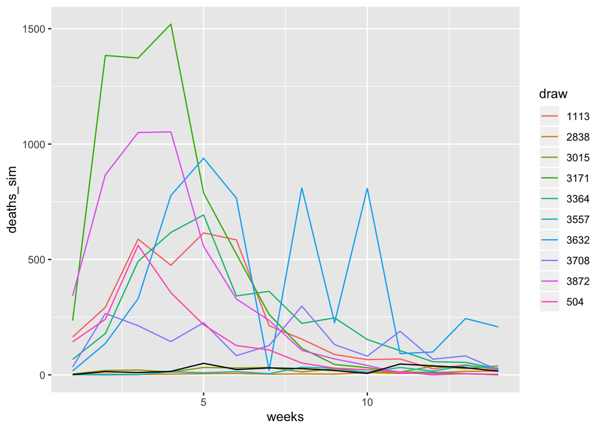

```r
stan_data_no_likelihood <- stan_data
stan_data_no_likelihood$compute_likelihood <- 0

fit_2 <- xfun::cache_rds({model$sample(data=stan_data_no_likelihood, seed=999,
                                           chains=num_chains, init = initf,
                                           num_warmup=num_warmup,
                                           num_samples=num_samples,
                                           output_dir="output")},
                             rerun=TRUE, file="fit2", dir="_cache/")

rs_fit_2 <- rstan::read_stan_csv(fit_2$output_files())
rs_ex_fit_2 <- rstan::extract(rs_fit_2)

random_draws <- sample(1:nrow(rs_ex_fit_2$pred_deaths), 10, replace=FALSE)
deaths_draws <- t(rs_ex_fit_2$pred_deaths[random_draws,])
deaths_draws.df <- data.frame(deaths_draws)
names(deaths_draws.df) <- random_draws
draw_names <- colnames(deaths_draws.df)
weeks <- 1:nrow(deaths_draws.df)
p_data2.df <- cbind(deaths,weeks,deaths_draws.df)

p_long_data <- gather(p_data2.df, draw, deaths_sim, draw_names)

p3 <- ggplot(data=p_long_data, aes(x=weeks)) +
            geom_line(aes(y=deaths_sim, group=draw, color=draw), size=.5) +
            geom_line(aes(y=deaths), color="black", size=.5)
p3
```

Above we see the posterior of the priors without seeing any data. Generally some justification for prior distributions is expected. The above are weakly informative in that they cover a broad range of plausible values.

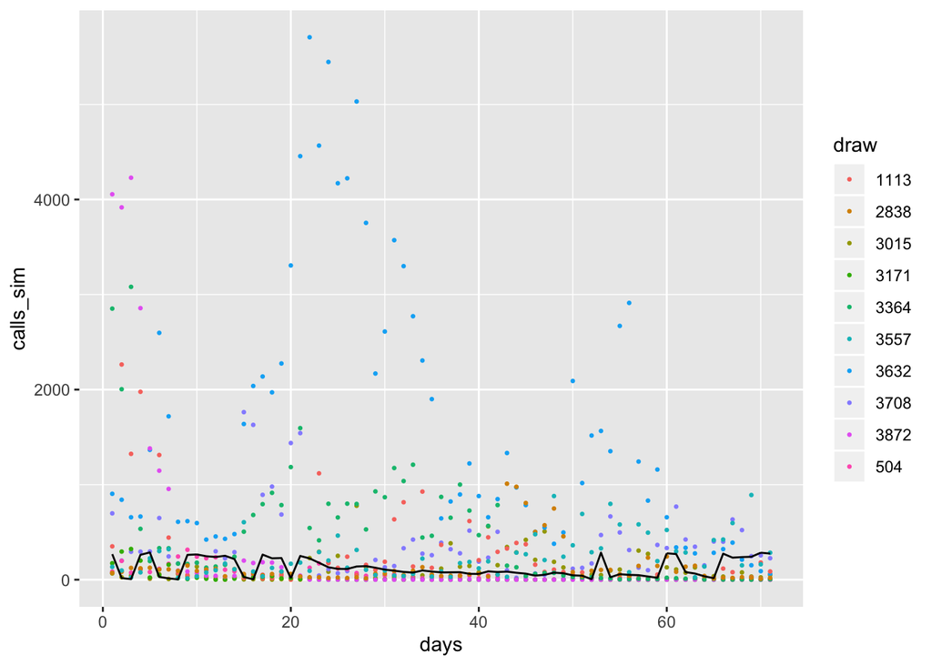

```r
call_draws <- t(rs_ex_fit_2$pred_calls_111[random_draws,]) #keep same draws
call_draws.df <- data.frame(call_draws)
names(call_draws.df) <- random_draws
days <- 1:nrow(call_draws.df)
p_data3.df <- cbind(calls_111,days,call_draws.df)

p_long_data3 <- gather(p_data3.df, draw, calls_sim, draw_names)

p4 <- ggplot(data=p_long_data3, aes(x=days)) +
            geom_point(aes(y=calls_sim, group=draw, color=draw), size=.5) +
            geom_line(aes(y=calls_111), color="black", size=.5)
p4
```

### Parameter recovery with simulated data

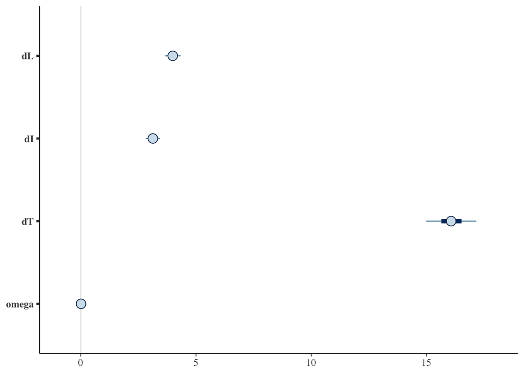

```r
library(bayesplot)
#Pick one arbitrary draw from the prior distribution
draw <- 42
stan_data_3 <- stan_data
stan_data_3$calls_111 <- rs_ex_fit_2$pred_calls_111[42,]
stan_data_3$deaths <- rs_ex_fit_2$pred_deaths[42,]
stan_data_3$compute_likelihood <- 1

fit_3 <- xfun::cache_rds({model$sample(data=stan_data_3, seed=999,
                                           chains=num_chains, init = initf,
                                           num_warmup=num_warmup,
                                           num_samples=num_samples,
                                           output_dir="output")},
                             rerun=TRUE, file="fit3", dir="_cache/")

rs_fit_3 <- rstan::read_stan_csv(fit_3$output_files())
rs_fit_3_draws <- rstan::extract(rs_fit_3)

mcmc_intervals(fit_3$draws(variables=c("dL", "dI", "dT","omega")))
```

```r
report <- paste(sprintf("Draw number %d", draw),
sprintf("actual dL=%.2f", rs_ex_fit_2$dL[draw]),
sprintf("actual dI=%.2f", rs_ex_fit_2$dI[draw]),
sprintf("actual dT=%.2f", rs_ex_fit_2$dT[draw]),
sprintf("actual omega=%.2f", rs_ex_fit_2$omega[draw]),
sep="\n")
cat(report)
```

```
Draw number 42
actual dL=3.81
actual dI=3.36
actual dT=16.43
actual omega=0.01
```

### Posterior predictive check

Compare predicted data from original run that used actual data.

#### Predict deaths

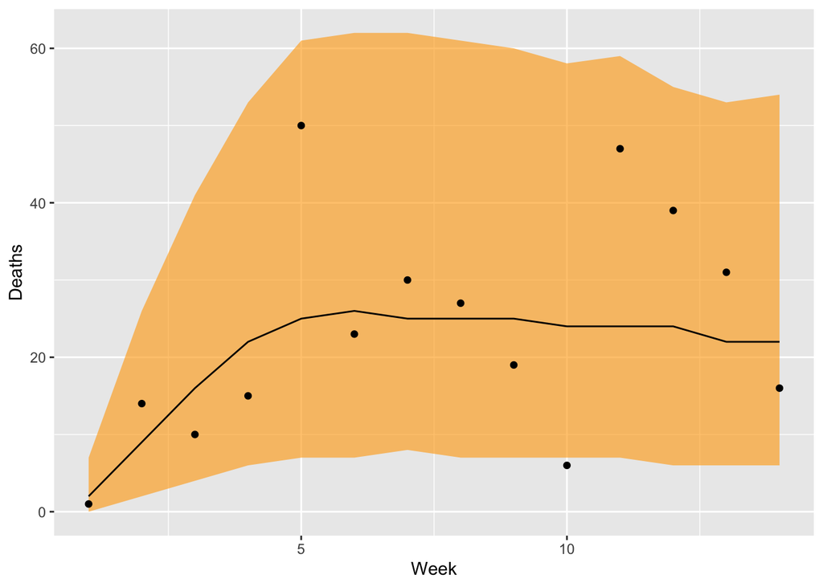

```r
rs_fit_1_draws <- rstan::extract(rs_fit_1)

summary.df <- as.data.frame(summary(rs_fit_1,pars=c("pred_deaths"), probs=c(.05,.5,.95))$summary)
weeks <- 1:length(deaths)
all.df <- cbind(summary.df, deaths, weeks)
colnames(all.df) <- make.names(colnames(all.df)) # to remove % in the col names

p4 <- ggplot(all.df, mapping = aes(x = weeks)) +
  geom_ribbon(aes(ymin = X5., ymax = X95.), fill = "orange", alpha = 0.6) +
  geom_line(mapping = aes(y = X50.)) +
  geom_point(mapping = aes(y = deaths)) +
  labs(x = "Week", y = "Deaths")
p4
```

#### Predict 111 calls

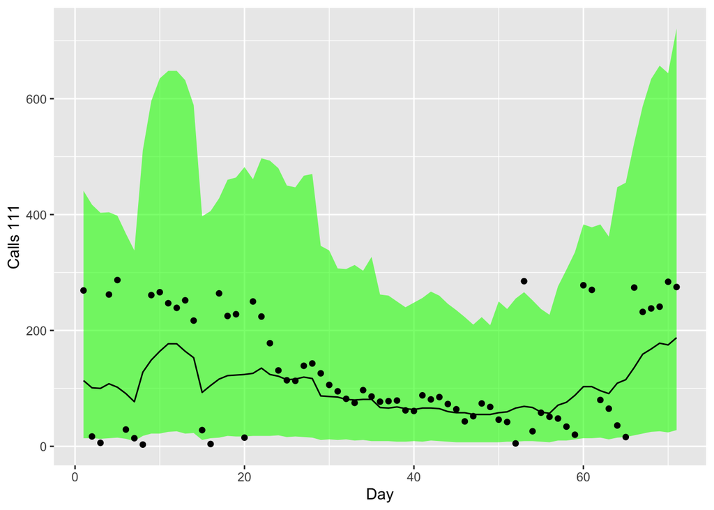

```r
rs_fit_1_draws <- rstan::extract(rs_fit_1)

summary_2.df <- as.data.frame(summary(rs_fit_1,pars=c("pred_calls_111"), probs=c(.05,.5,.95))$summary)
days <- 1:length(calls_111)
all_2.df <- cbind(summary_2.df, calls_111, days)
colnames(all_2.df) <- make.names(colnames(all_2.df)) # to remove % in the col names

p5 <- ggplot(all_2.df, mapping = aes(x = days)) +
  geom_ribbon(aes(ymin = X5., ymax = X95.), fill = "green", alpha = 0.6) +
  geom_line(mapping = aes(y = X50.)) +
  geom_point(mapping = aes(y = calls_111)) +
  labs(x = "Day", y = "Calls 111")
p5
```

### Parameter interpretation

Impact of param changes on predictions.

### SBC validation

[output not shown]